# DY2022_Thalassiosira_Run4

## Format ddata for microviz

Only Thalassiosira

```r
# subset dataframe
Th_ps<-subset_taxa(all_ps, Genus=="Thalassiosira")
all_ps_surf<-all_ps %>% subset_samples(depth_max<5)
Th_ps_surf<-Th_ps %>% subset_samples(depth_max<5)

# ord_explore(all_ps_surf)
```

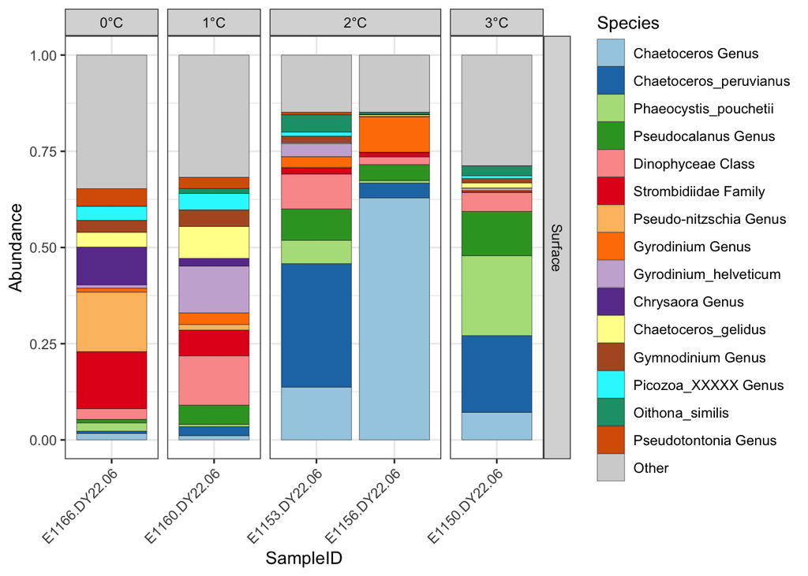

```r
# Check out bargraph
all_ps %>%
  ps_mutate(depth_gp = case_when(depth_max<5 ~ "Surface",
                                 depth_max>5 & depth_max<40 ~ "Mid-Depth",
                                 depth_max>40 ~ "Deep"),
            temp_int = round(temp),
            temp_gp = case_when(temp_int==0 ~ "0°C",
                                temp_int==1 ~ "1°C",
                                temp_int==2 ~ "2°C",
                                temp_int==3 ~ "3°C")) %>%
  ps_filter(depth_gp=="Surface") %>%
  # ps_arrange(desc(temp_int)) %>%
  comp_barplot(
    tax_level = "Species",
    n_taxa = 15,
    sample_order = "default",
    bar_width = 0.9,
    bar_outline_colour = "black",
    #palette=distinct_palette(pal = "kelly", add = "lightgrey"),
    order_with_all_taxa = TRUE#,
    # label = "temp_int"
  ) +
  # labs(x=expression(Temperature*degree*C)) +
  labs(x="SampleID") +
  facet_grid(depth_gp~ temp_gp, scales="free", space="free") +
  theme_bw() +
  theme(axis.text.x = element_text(angle = 45,hjust=1))
```

```r
# save plot:
ggsave(
    here("figures","DY2206_All_bargraph_surface.png"),
    device = "png",
    width = 12,
    height = 10,
    units = "in"
  )
```

Bargraph of Thalassiosira across three depths:

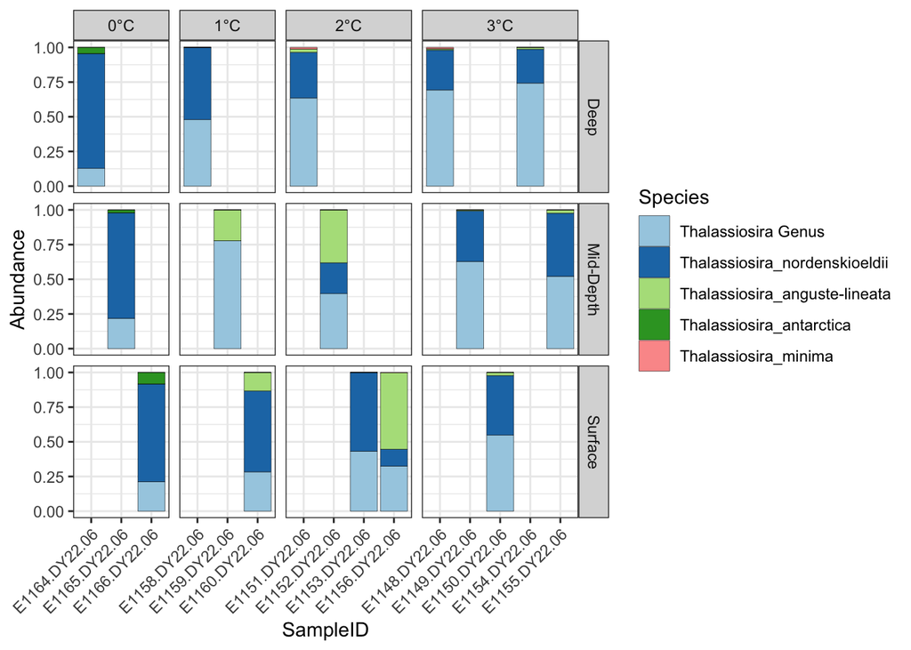

```r
# Check out bargraph
Th_ps %>%
  ps_mutate(depth_gp = case_when(depth_max<5 ~ "Surface",
                                 depth_max>5 & depth_max<40 ~ "Mid-Depth",
                                 depth_max>40 ~ "Deep"),
            temp_int = round(temp),
            temp_gp = case_when(temp_int==0 ~ "0°C",
                                temp_int==1 ~ "1°C",
                                temp_int==2 ~ "2°C",
                                temp_int==3 ~ "3°C")) %>%
  # ps_filter(depth_gp=="Surface") %>%
  ps_arrange(dplyr::desc(temp_int)) %>%
  comp_barplot(
    tax_level = "Species",
    sample_order = "default",
    bar_width = 0.9,
    bar_outline_colour = "black",
    order_with_all_taxa = TRUE#,
    # label = "temp_int"
  ) +
  # labs(x=expression(Temperature*degree*C)) +
  labs(x="SampleID") +
  facet_grid(depth_gp~ temp_gp, scales="free", space="free") +
  theme_bw() +
  theme(axis.text.x = element_text(angle = 45,hjust=1))
```

```r
# save plot:
ggsave(
    here("figures","DY2206_Th_bargraph.png"),
    device = "png",
    width = 12,
    height = 10,
    units = "in"
  )
```

## Ordination plot with MicroViz

NMDS plot of all protists

```r
# filter non-phyto taxa:
all_ps_filt<-subset_taxa(all_ps_surf, Domain=="Eukaryota" & Family!="Strombidiidae" & Genus!="Pseudocalanus" & Subdivision!="Metazoa" & Subdivision!="Fungi" & Subdivision!="Eukaryota Domain" & Subdivision!="Rotosphaerida" & Subdivision!="Apusomonada" & Subdivision!="Discosea" & Subdivision!="Tubulinea" & Subdivision!="Fornicata" & Subdivision!="Amoebozoa_XX")
#ordination with microviz:
# ord_explore(all_ps_filt)

# Ordination plot of all taxa:
all_ps_surf_nmds_calc<- all_ps_filt %>%
 tax_transform(rank = "unique", trans = "binary") %>%
 dist_calc(dist = "bray") %>%
 ord_calc(
  method = "NMDS"
 )
```

```
## *** Best solution was not repeated -- monoMDS stopping criteria:
##     15: stress < smin
##      3: stress ratio > sratmax
##      2: scale factor of the gradient < sfgrmin
```

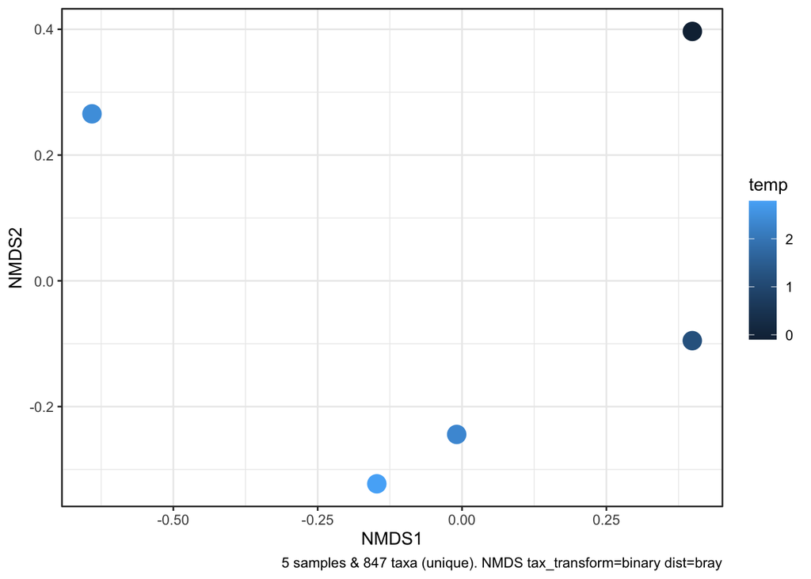

```r
# get the distance matrix:
all_ps_surf_nmds_dist<-dist_get(all_ps_surf_nmds_calc)

# plot ordination
all_ps_surf_nmds<- all_ps_surf_nmds_calc %>%
  ord_plot(
  axes = c(1, 2),
  colour = "temp", fill = "temp",
  shape = 21, alpha = 1,
  size = 5
 ) +
  theme_bw()
  #guides(color = "none") +
  # guides(fill=guide_legend(title=expression(Temperature*degree*C)),
  #       color=guide_legend(title=expression(Temperature*degree*C)))

all_ps_surf_nmds
```

```r
# save plot:
ggsave(
    plot = all_ps_surf_nmds,
    here("figures","DY2206_All_phytos_NMDS_microviz.png"),
    device = "png",
    width = 10,
    height = 8,
    units = "in"
  )
```

## Improved ordination with ggplot:

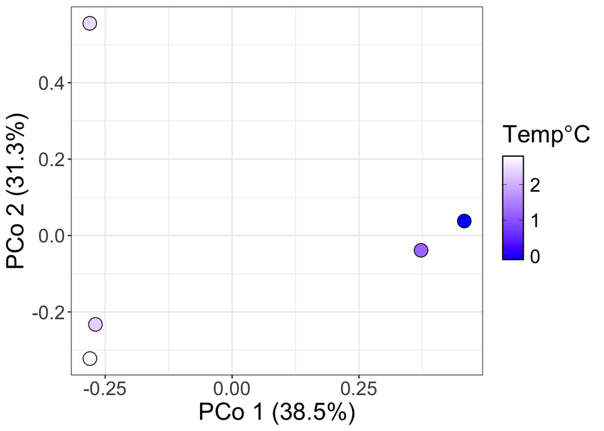

```r
# save otu table:
all_ps_filt_otu<-t(otu_table(all_ps_filt)) %>% data.frame()

# save environmental data:
dy2206_surf_phyto_env<-sample_data(all_ps_filt) %>%
  data.frame() %>%
  rownames_to_column(var="Sample") %>%
  dplyr::select("Sample","temp")

# calc PCoA:
dy2206_surf_phyto_dist <- vegdist(all_ps_filt_otu,method="jaccard")
dy2206_surf_phyto_pcoa <- cmdscale(dy2206_surf_phyto_dist, eig = TRUE, k=2, add=TRUE) # add makes all eigen positive
# checking out pcoa plot:
# ordiplot(dy2206_surf_phyto_pcoa, display = 'sites', type = 'text')
# barplot(dy2206_surf_phyto_pcoa$eig, names = paste ('PCoA', 1:5), las = 3, ylab = 'eigenvalues')


# calc nmds
# dy2206_surf_phyto_metaMDS<-metaMDS(all_ps_filt_otu, distance='jaccard', trymax=100)

# save 'site' scores to plot
site.scrs <- as.data.frame(scores(dy2206_surf_phyto_pcoa, display = "sites")) %>%
  dplyr::rename("pcoa1"=Dim1,"pcoa2"=Dim2)
# calculate percent explained:
perc_explained<-round(100*(dy2206_surf_phyto_pcoa$eig/sum(dy2206_surf_phyto_pcoa$eig)), digits=1)
labs=c(glue("PCo 1 ({perc_explained[1]}%)"),
       glue("PCo 2 ({perc_explained[2]}%)"))

# join with environmental for plotting:
site.scrs_v2 <-site.scrs %>%
  rownames_to_column(var="Sample") %>%
  left_join(dy2206_surf_phyto_env)
# Ordination plot of all taxa:
all_phytos_pcoa<-ggplot(site.scrs_v2, aes(x=pcoa1, y=pcoa2))+ #sets up the plot
  geom_point(aes(pcoa1, pcoa2, fill = temp),
                 shape = 21, color="black", size = 5) +
  theme_bw() +
  labs(fill=expression(Temp*degree*C),x=labs[1],y=labs[2]) +
  scale_fill_gradient(low = "blue", high = "white",guide=guide_colorbar(frame.colour = "black", ticks.colour = "black")) +
  theme(plot.title = element_text(hjust=0.5, size=14),
        text=element_text(size=20))

# view plot
all_phytos_pcoa
```

```r
# save plot:
ggsave(
    plot = all_phytos_pcoa,
    here("figures","DY2206_All_phytos_pcoa.png"),
    device = "png",
    width = 8,
    height = 6,
    units = "in"
  )
```

## Composition with ordination from microviz:

```r
# Ordination plot of all taxa:
all_ps_surf_nmds_iris<- all_ps_filt %>%
 tax_transform(rank = "unique", trans = "binary") %>%
 dist_calc(dist = "bray") %>%
 ord_calc(
  method = "NMDS"
 ) %>%
  ord_plot_iris(tax_level = "Genus", ord_plot = "above", anno_colour = "temp",
                sizze=5)
```

```
## *** Best solution was not repeated -- monoMDS stopping criteria:
##     15: stress < smin
##      3: stress ratio > sratmax
##      2: scale factor of the gradient < sfgrmin
```

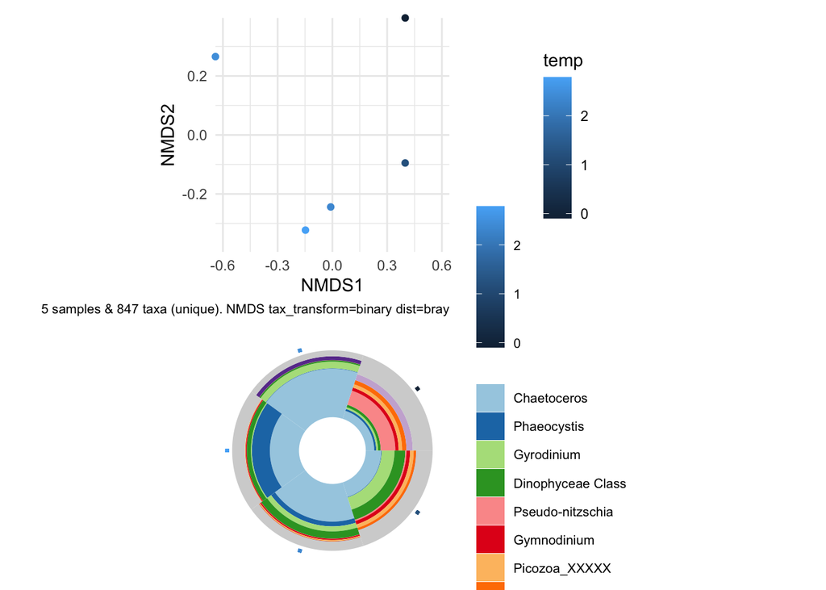

```r
# view plot
all_ps_surf_nmds_iris
```

```r
# save plot:
ggsave(
    plot = all_ps_surf_nmds_iris,
    here("figures","DY2206_All_phytos_NMDS_wIRIS_microviz.png"),
    device = "png",
    width = 10,
    height = 10,
    units = "in"
  )
```

## Example of constrained ordination from microviz

Note not the best stats, will follow GUSTAME tutorial later in script:

```r
# Ordination plot of all taxa:
all_ps_surf_const_calc <- all_ps_filt %>%
  tax_transform(rank = "unique", trans = "binary") %>%
 dist_calc(dist = "bray") %>%
 ord_calc(
  constraints = c("temp"),
  method = "auto"
 )
```

```
##
## Centering (mean) and scaling (sd) the constraints and/or conditions:
```

```
##  temp
```

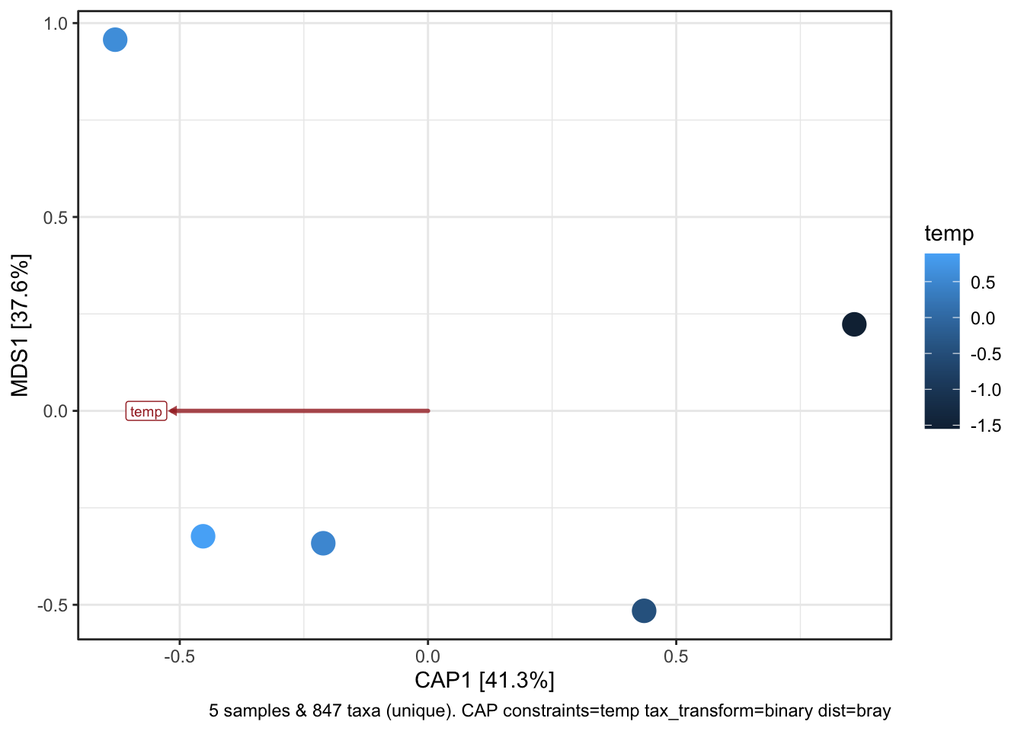

```r
# plot ordination
all_ps_surf_const<- all_ps_surf_const_calc %>%
  ord_plot(
  axes = c(1, 2),
  colour = "temp", fill = "temp",
  shape = "circle", alpha = 1,
  size = 5
 ) +
  theme_bw()
  #guides(color = "none") +
  # guides(fill=guide_legend(title=expression(Temperature*degree*C)),
  #       color=guide_legend(title=expression(Temperature*degree*C)))

# view plot
all_ps_surf_const
```

```r
# save plot:
ggsave(
    plot = all_ps_surf_const,
    here("figures","DY2206_All_phytos_CCA_microviz.png"),
    device = "png",
    width = 10,
    height = 8,
    units = "in"
  )
```

## Map of Sampling

Create blank map of Alaska:

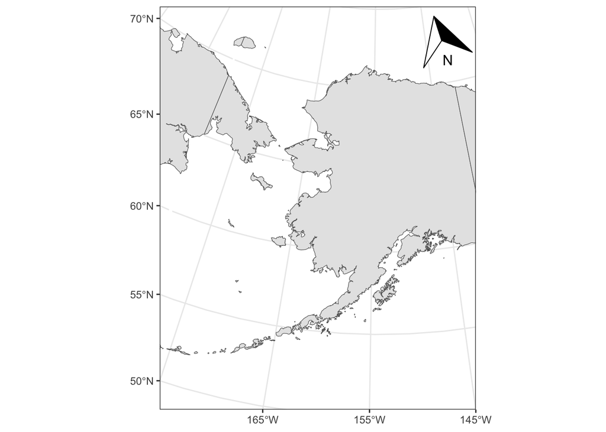

convert environmental data lat/lon for map projection distortion:

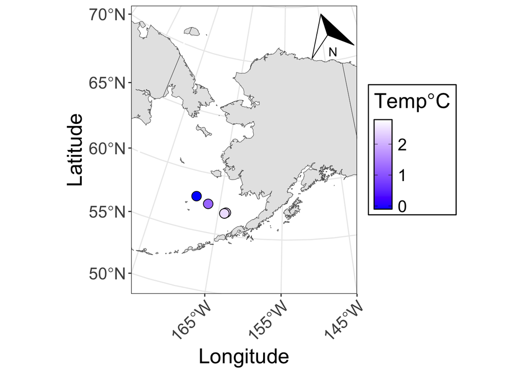

## Heatmap of Thalassiosira Occurence:

## Presence and absence of Species for each region:

```r
all_ps_surf_pa <- all_ps_surf %>%
  # transform_sample_counts(function(x) ifelse(x > 0, 1, 0))
  tax_transform("pa",rank=NA)

# Convert phyloseq object to a dataframe:
Th_ps_surf_pa<-subset_taxa(all_ps_surf_pa, Genus=="Thalassiosira") %>%
  psmelt() %>%
  dplyr::rename(pres=Abundance) %>% # rename presence/absence columns
  mutate(temp_int=as.factor(round(temp,1))) %>% # create a new column with rounded temperature
  mutate(Temp_gp=case_when(temp<2 ~ "0-2",
                           temp>=2 ~ "2-3")) %>%
  group_by(Temp_gp, Genus, Species) %>%
  summarise(occurence=sum(pres)) %>%
  mutate(presence=ifelse(occurence > 0, 1, 0)) %>%
  group_by(Temp_gp, Genus, Species) %>% filter(sum(occurence) >= 1) %>% # remove species without occurence at the surface.
  ungroup() %>%
  complete(Temp_gp, Genus,Species,fill = list(presence = 0, occurence = 0)) %>% # add zeros for species and temperature combos that were not observed.
  mutate(presence=as.factor(presence)) %>% # convert presence to a factor.
  mutate(Species=str_replace(Species,"_", " "))# remove underscore from species id.
```

Occurence heatmap with species

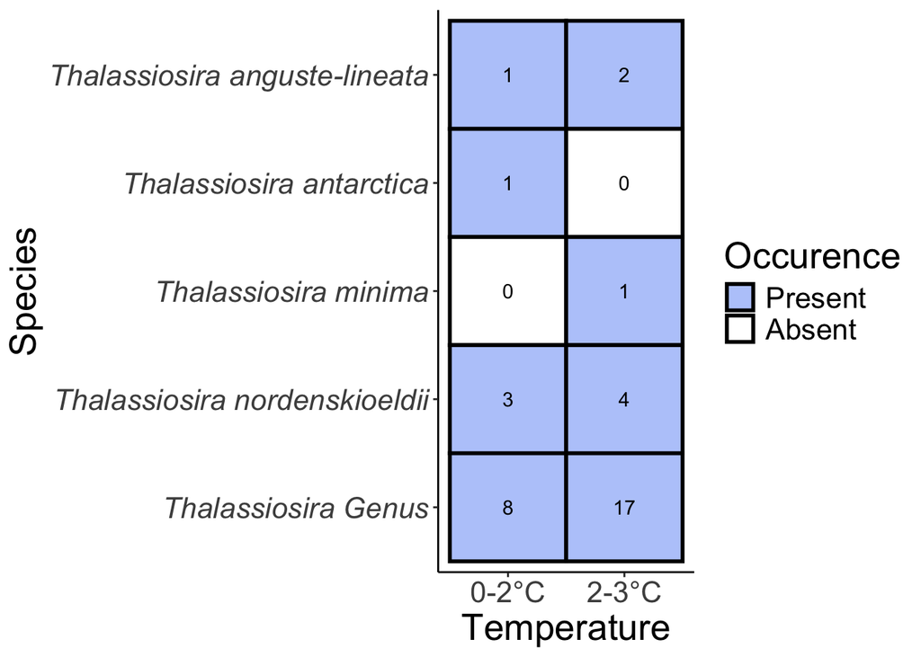

```r
# Change the order of Species:
Th_ps_surf_pa_v2 <- Th_ps_surf_pa %>%
  mutate(Species=as.factor(Species)) %>%
  mutate(Species=fct_relevel(Species,c("Thalassiosira anguste-lineata","Thalassiosira antarctica",
                                       "Thalassiosira delicatula","Thalassiosira minima",
                                       "Thalassiosira nordenskioeldii","Thalassiosira Genus")),
         Temp_gp=fct_relevel(Temp_gp, "0-2"))

# Heatmap of presence/absence of each HAB by metabarcoding region:
Th_ps_surf_pa_geomtile<- ggplot(Th_ps_surf_pa_v2, aes(x = Temp_gp, y = reorder(Species, dplyr::desc(Species)), fill = presence)) +
  geom_tile(color = "black", size=1) +
  geom_text(aes(label=occurence), color="black") +
  scale_fill_manual(breaks = c( "1","0"),
                       values=c("#B9CBFA", "white"), # (other color options, navy blue:#192B41)
                       labels=c("Present","Absent")) +
  scale_x_discrete(labels = ~ paste0(.x, "\u00B0","C")) +
  labs(fill="Occurence",y="Species",x="Temperature") +
  theme_classic() +
  theme(axis.text.y = element_text(face = "italic"),
        text=element_text(size=20))
# show plot
Th_ps_surf_pa_geomtile
```

```r
# save figure
ggsave(
  file = here::here("figures","Dyson_2022_Th_pres_occ.pdf"),
  width = 8,
  height = 6, limitsize = FALSE
)
```

Occurence heatmap with ASVs

```r
# Convert phyloseq object to a dataframe:
Th_genus_surface<-subset_taxa(all_ps_surf_pa, Species=="Thalassiosira Genus") %>%
  psmelt() %>%
  left_join(asv_seq_id %>% dplyr::select("ASV","seq_id"), by=c("unique"="seq_id")) %>%
  dplyr::select(-"OTU") %>%
  dplyr::rename(pres=Abundance) %>% # rename presence/absence columns
  mutate(temp_int=as.factor(round(temp,1))) %>% # create a new column with rounded temperature
  mutate(Temp_gp=case_when(temp<2 ~ "0-2",
                           temp>=2 ~ "2-3")) %>%
  group_by(Temp_gp, Species, ASV) %>%
  summarise(occurence=sum(pres)) %>%
  mutate(presence=ifelse(occurence > 0, 1, 0)) %>%
  group_by(Temp_gp, Species, ASV) %>% filter(sum(occurence) >= 1) %>% # remove species without occurence at the surface.
  ungroup() %>%
  complete(Temp_gp,Species,ASV,fill = list(presence = 0, occurence = 0)) %>% # add zeros for species and temperature combos that were not observed.
  mutate(presence=as.factor(presence)) # convert presence to a factor.
```

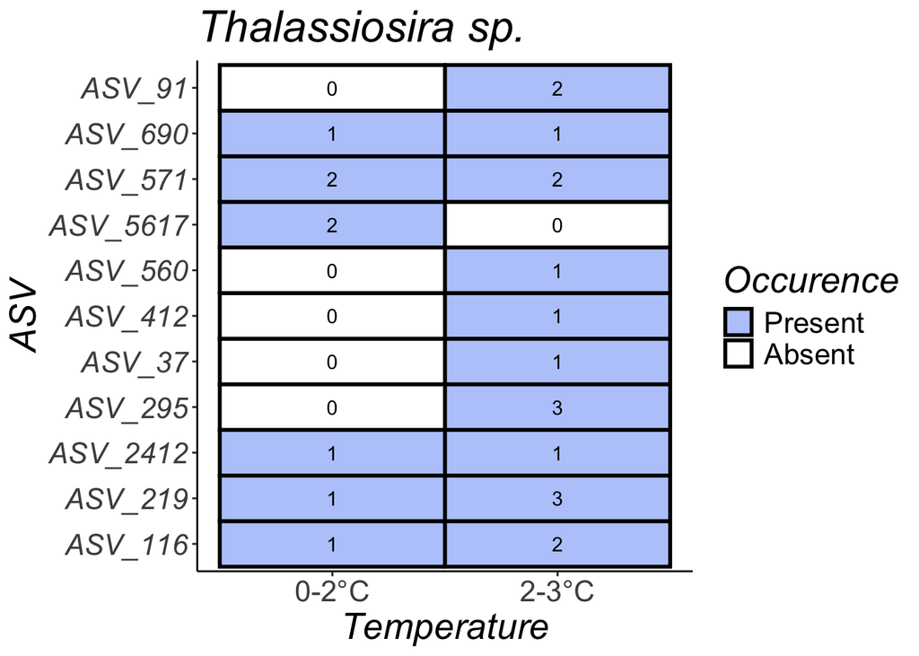

```r
# Change the order of Species:
Th_genus_surface_v2 <- Th_genus_surface %>%
  mutate(ASV=as.factor(ASV),
         Temp_gp=fct_relevel(Temp_gp, "0-2"))

# Heatmap of presence/absence of each HAB by metabarcoding region:
Th_genus_surf_geomtile<- ggplot(Th_genus_surface_v2, aes(x = Temp_gp, y = ASV, fill = presence)) +
  geom_tile(color = "black", size=1) +
  geom_text(aes(label=occurence), color="black") +
  scale_fill_manual(breaks = c( "1","0"),
                       values=c("#B9CBFA", "white"), # (other color options, navy blue:#192B41)
                       labels=c("Present","Absent")) +
  scale_x_discrete(labels = ~ paste0(.x, "\u00B0","C")) +
  labs(fill="Occurence",y="ASV",x="Temperature", title="Thalassiosira sp.") +
  theme_classic() +
  theme(axis.text.y = element_text(face = "italic"),
        title=element_text(face="italic"),
        text=element_text(size=20))
# show plot
Th_genus_surf_geomtile
```

```r
# save figure
ggsave(
  file = here::here("figures","Dyson_2022_Th_genus_occ.png"),
  width = 8,
  height = 8, limitsize = FALSE
)
```

## RDA of phytoplankton community with temp: *Note:After running through analysis, not ideal with only one variable, so back to NMDS with temperature filled in*

Following GUSTAME tutorial

Transform counts to presence/absence

```r
# save otu table:
all_ps_filt_otu<-t(otu_table(all_ps_filt)) %>% data.frame()

# save environmental data:
dy2206_surf_phyto_env<-sample_data(all_ps_filt) %>%
  data.frame() %>%
  rownames_to_column(var="Sample") %>%
  dplyr::select("Sample","temp")

# save taxonomy table:
dy2206_surf_phyto_taxa<-tax_table(all_ps_filt) %>% data.frame()

# Use decostand to transform sample counts to presence/absence (pa):
dy2206_surf_phyto_presabs <- decostand(all_ps_filt_otu, "pa")

# Run a decorona analysis to determine if species distribution is linear or uni-modal:
dca_raw_phytos<-decorana(dy2206_surf_phyto_presabs)
dca_raw_phytos
```

```
##
## Call:
## decorana(veg = dy2206_surf_phyto_presabs)
##
## Detrended correspondence analysis with 26 segments.
## Rescaling of axes with 4 iterations.
## Total inertia (scaled Chi-square): NaN
##
##                        DCA1 DCA2 DCA3 DCA4
## Eigenvalues          0.3944    0    0    0
## Additive Eigenvalues 0.0000    0    0    0
## Decorana values      0.4042    0    0    0
## Axis lengths         2.2594    0    0    0
```

To decide whether to apply linear or unimodal ordination method on your data, you can use the rule of thumb introduced by Lepš & Šmilauer (2003): first, calculate DCA (detrended by segments) on your data, and check the length of the first DCA axis (which is scaled in units of standard deviation, S.D.). The length of first DCA axis > 4 S.D. indicates a heterogeneous dataset on which unimodal methods should be used, while the length < 3 S.D. indicates a homogeneous dataset for which linear methods are suitable (see Fig. 5. In the grey zone between 3 and 4 S.D., both linear and unimodal methods are OK. Note that while linear methods should not be used for heterogeneous data, unimodal methods can be used for homogeneous data, but linear methods, in this case, are more powerful and should be preferred. Alternatively, if your data are heterogeneous, but you still want to use linear ordination methods (PCA, RDA), apply them on Hellinger transformed species composition data to calculate ordination based on Hellinger distances (as recommended e.g. by Legendre & Gallagher (2001)).

**Axis length for DY2206 all phytos was less than 3 and therefore linear methods (RDA) is appropriate.**

Normality of untransformed environmental data: temp

```r
# Statistical test for normality:
shapiro.test(dy2206_surf_phyto_env$temp)
```

```
##
##  Shapiro-Wilk normality test
##
## data:  dy2206_surf_phyto_env$temp
## W = 0.87619, p-value = 0.2924
```

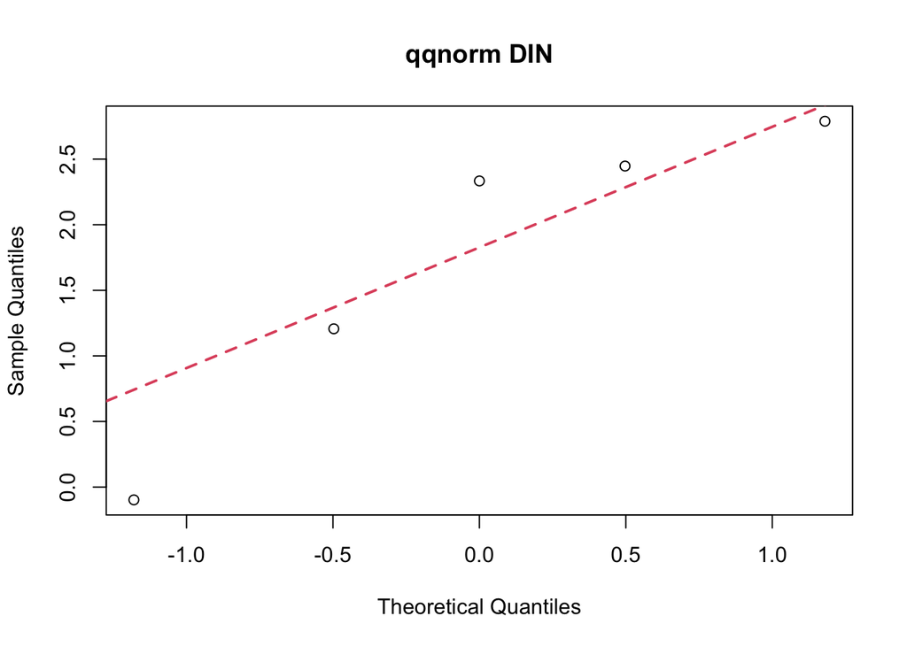

```r
# Check distribution of final list of environmental variables to include:
qqnorm(dy2206_surf_phyto_env$temp, main="qqnorm DIN"); qqline(dy2206_surf_phyto_env$temp, col = 2,lwd=2,lty=2)
```

Conclusion: normality assumptions met!

Could apply z-score to environmental data, but only looking at temperature, so not neccessary (if more than one environmental this is important so they are on the same scale).

### calculate the tb-RDA (since pres-absence)

```r
# RDA analysis:
dy2206_RDA<-rda(dy2206_surf_phyto_presabs ~ temp, data=dy2206_surf_phyto_env, na.action=na.omit)
dy2206_RDA
```

```
##
## Call: rda(formula = dy2206_surf_phyto_presabs ~ temp, data =
## dy2206_surf_phyto_env, na.action = na.omit)
##
##                Inertia Proportion Rank
## Total         147.7000     1.0000
## Constrained    51.2138     0.3467    1
## Unconstrained  96.4862     0.6533    3
##
## Inertia is variance
##
## Eigenvalues for constrained axes:
##  RDA1
## 51.21
##
## Eigenvalues for unconstrained axes:
##   PC1   PC2   PC3
## 42.01 31.28 23.20
```

```r
# Overall test of the significance of the analysis
anova(dy2206_RDA)
```

```
## 'nperm' >= set of all permutations: complete enumeration.
```

```
## Set of permutations < 'minperm'. Generating entire set.
```

```
## Permutation test for rda under reduced model
## Permutation: free
## Number of permutations: 119
##
## Model: rda(formula = dy2206_surf_phyto_presabs ~ temp, data = dy2206_surf_phyto_env, na.action = na.omit)
##          Df Variance      F  Pr(>F)
## Model     1   51.214 1.5924 0.01667 *
## Residual  3   96.486
## ---
## Signif. codes:  0 '***' 0.001 '**' 0.01 '*' 0.05 '.' 0.1 ' ' 1
```

```r
# test axes for sig. Or, we may calculate the significance of each constrained axis independently. This can be done by adding argument by = “axis” (by default, the argument by is set to NULL, see the helpfile ?anova.cca). The calculation takes rather long (there are 14 constrained axes, each tested separately); you may speed it up using parallel calculation if your computer has more than one core (use the argument parallel with the number of available cores, four in the case of my computer). Also, we will directly store the results into an object (test_axis) so as we can call it later for further processing:
test_axis<- anova(dy2206_RDA, by = "axis", perm.max = 999)
```

```
## 'nperm' >= set of all permutations: complete enumeration.
## Set of permutations < 'minperm'. Generating entire set.
```

```r
test_axis
```

```
## Permutation test for rda under reduced model
## Forward tests for axes
## Permutation: free
## Number of permutations: 119
##
## Model: rda(formula = dy2206_surf_phyto_presabs ~ temp, data = dy2206_surf_phyto_env, na.action = na.omit)
##          Df Variance      F  Pr(>F)
## RDA1      1   51.214 1.5924 0.01667 *
## Residual  3   96.486
## ---
## Signif. codes:  0 '***' 0.001 '**' 0.01 '*' 0.05 '.' 0.1 ' ' 1
```

```r
# Adjust p-values for multiple tests:
test_axis.adj <- test_axis
test_axis.adj$`Pr(>F)` <- p.adjust (test_axis$`Pr(>F)`, method = 'holm')
test_axis.adj
```

```
## Permutation test for rda under reduced model
## Forward tests for axes
## Permutation: free
## Number of permutations: 119
##
## Model: rda(formula = dy2206_surf_phyto_presabs ~ temp, data = dy2206_surf_phyto_env, na.action = na.omit)
##          Df Variance      F  Pr(>F)
## RDA1      1   51.214 1.5924 0.01667 *
## Residual  3   96.486
## ---
## Signif. codes:  0 '***' 0.001 '**' 0.01 '*' 0.05 '.' 0.1 ' ' 1
```

```r
# test for significance of env. variables; however this tests sequentially adds each variable one by one in order in which they enter the model formula, and for each calculates partial explained variation and its significance with previous variables as covariables (i.e. for the first variable it is marginal variation explained by this variable and its significance, for the second variable it is partial variation explained by the second variable after removing the variation of the first variable as covariable, etc.). Since variables in the dataset are ordered without exact meaning, this option is not useful here.
anova(dy2206_RDA, by = "terms", permu = 999)
```

```
## 'nperm' >= set of all permutations: complete enumeration.
## Set of permutations < 'minperm'. Generating entire set.
```

```
## Permutation test for rda under reduced model
## Terms added sequentially (first to last)
## Permutation: free
## Number of permutations: 119
##
## Model: rda(formula = dy2206_surf_phyto_presabs ~ temp, data = dy2206_surf_phyto_env, na.action = na.omit)
##          Df Variance      F  Pr(>F)
## temp      1   51.214 1.5924 0.01667 *
## Residual  3   96.486
## ---
## Signif. codes:  0 '***' 0.001 '**' 0.01 '*' 0.05 '.' 0.1 ' ' 1
```

```r
# by = “margin”, testing the variance explained by each explanatory variable with all the others used as covariables (independently from their order in the model):
anova(dy2206_RDA, by = "margin", permu = 999)
```

```
## 'nperm' >= set of all permutations: complete enumeration.
## Set of permutations < 'minperm'. Generating entire set.
```

```
## Permutation test for rda under reduced model
## Marginal effects of terms
## Permutation: free
## Number of permutations: 119
##
## Model: rda(formula = dy2206_surf_phyto_presabs ~ temp, data = dy2206_surf_phyto_env, na.action = na.omit)
##          Df Variance      F  Pr(>F)
## temp      1   51.214 1.5924 0.01667 *
## Residual  3   96.486
## ---
## Signif. codes:  0 '***' 0.001 '**' 0.01 '*' 0.05 '.' 0.1 ' ' 1
```

Statistical output: - ANOVA of RDA model: F(1,3)=1.59, p=0.01667

How much variation is explained by each axis

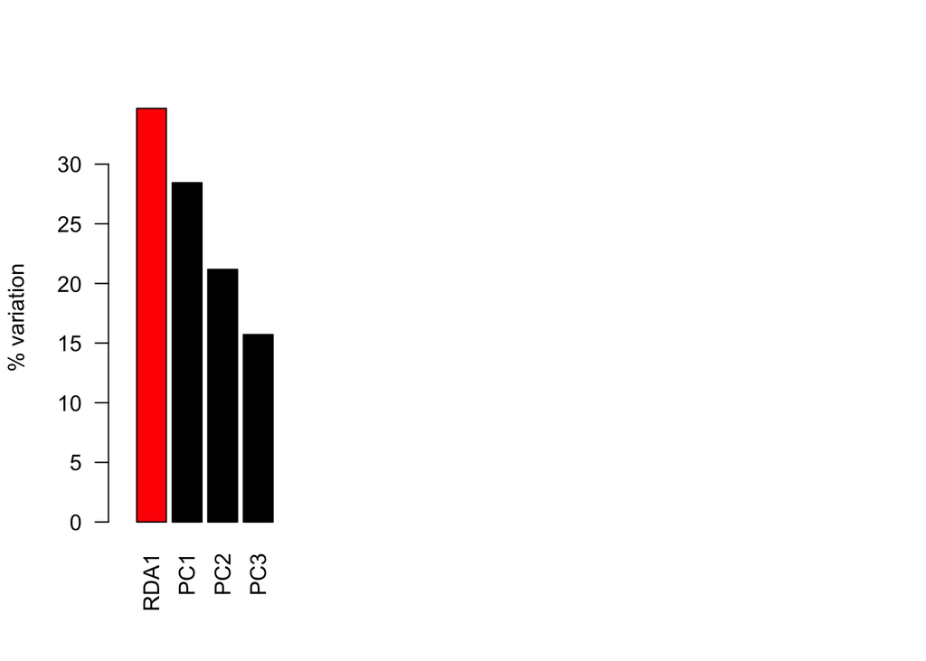

```r
constrained_eig <- dy2206_RDA$CCA$eig/dy2206_RDA$tot.chi*100
unconstrained_eig <- dy2206_RDA$CA$eig/dy2206_RDA$tot.chi*100
expl_var <- c(constrained_eig, unconstrained_eig)
barplot (expl_var[1:20], col = c(rep ('red', length (constrained_eig)), rep ('black', length (unconstrained_eig))),
         las = 2, ylab = '% variation')
```

Check RDA plot:

Type 2: Angles between variables reflect their correlation. Longer arrows mean this variable strongly drives the variation in the community matrix, Arrows pointing in opposite directions have a negative relationship, Arrows pointing in the same direction have a positive relationship.

Type 1: Distances among objects reflect their similarities. Sites (numbers) that are closer together have more similar communities, Species that are closer together occupy more sites in common.

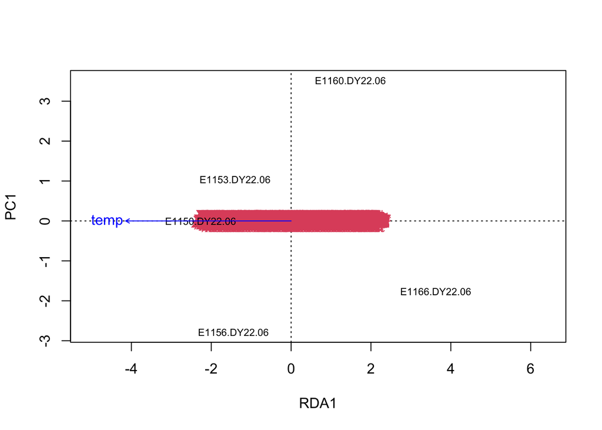

```r
# Type 2 scaling
ordiplot(dy2206_RDA, scaling = 2, type = "text")
```

Save ouptput for plotting:

```r
# Custom triplot code!

## extract % explained by the first 2 axes
perc <- round(100*(summary(dy2206_RDA)$cont$importance[2, 1:2]), 2)

## extract scores - these are coordinates in the RDA space
site_df <- scores(dy2206_RDA, display="sites", choices=c(1,2), scaling=2)
df_species <- as.data.frame(scores(dy2206_RDA, display="species", choices=c(1,2), scaling=2))
env_rda_sig <- scores(dy2206_RDA, display="bp", choices=c(1, 2), scaling=2)
env_rda_sig <- as.data.frame(env_rda_sig)
env_rda_sig$env<-row.names(env_rda_sig)
```

Customize Plot:

```r
## Custom triplot, step by step

# re-name value:
env_rda_sig2 <- env_rda_sig %>%
mutate(env=replace(env, env=="temp", "Temperature"))

# COlors for plots from ggsci: https://cran.r-project.org/web/packages/ggsci/vignettes/ggsci.html
Regionpal = pal_uchicago("default")(3)
Regionpal
```

```
## [1] "#800000FF" "#767676FF" "#FFA319FF"
```

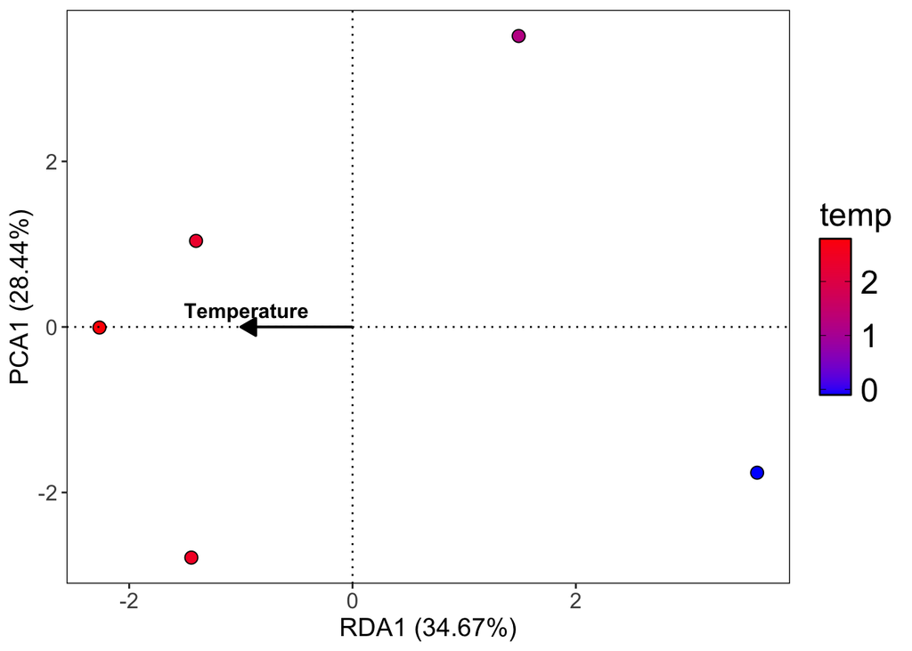

```r
# Add transect_id colors to rda:
site_df<-as.data.frame(site_df)
site_df$Sample <- row.names(site_df)
site_df_env<-left_join(site_df, dy2206_surf_phyto_env, by="Sample")

# now for plotting, first the sample sites:
rda_plot <- ggplot() +
  geom_point(data=site_df_env, aes(x=RDA1, y=PC1, fill=temp),shape=21, color="black", size=3) +
  scale_fill_gradient(low = "blue", high = "red",guide=guide_colorbar(frame.colour = "black", ticks.colour = "black")) +
  geom_hline(yintercept=0, linetype="dotted") +
  geom_vline(xintercept=0, linetype="dotted") +
  xlab(paste0("RDA1 (", perc[1],"%)")) +
  ylab(paste0("PCA1 (", perc[2],"%)")) +
  # labs(fill="Region") +
  theme(panel.border = element_rect(colour = "black", fill=NA, size=0.5),
        panel.background = element_blank(),
        axis.title = element_text(size = 14),
        axis.text = element_text(size = 12),
        legend.key=element_blank())

# Then the environment
rda_biplot<-rda_plot +
  geom_segment(data=env_rda_sig2, aes(x=0, xend=RDA1, y=0, yend=PC1), arrow=arrow(length = unit(0.03, "npc"), type="closed"), size = 0.7, colour = "black") +
  geom_text(data=env_rda_sig2, aes(x=RDA1, y=PC1,label=env), size=4, color="black", fontface="bold", nudge_x = 0.05, nudge_y = 0.2) +
  theme(legend.title=element_text(size=18),
        legend.text=element_text(size=18))

rda_biplot
```

```r
ggsave(
  file = here::here("figures", "DY2206_allPhytos_rda.png"),
  width = 6,
  height = 6, limitsize = FALSE
)
```

## Save environmental data to match to satellite data:

```r
# save environmental data:
dy2206_surf_phyto_env<-sample_data(all_ps_filt) %>%
  data.frame() %>%
  rownames_to_column(var="Sample") %>%
  dplyr::select("Sample","decimalLatitude","decimalLongitude","temp","minimumDepthInMeters","maximumDepthInMeters")


DY2206_for_sat<-read_delim(here(data_dir,
                                  "SKQ_Alaska_Analysis",
                                  "SKQ_Alaska_data",
                                  "processed",
                                  "dy2206_faire.csv")) %>%
  mutate(samp_name=gsub("\\-", ".", samp_name)) %>%
  dplyr::rename("Sample"=samp_name) %>%
  filter(Sample %in% dy2206_surf_phyto_env$Sample)  %>%
  dplyr::select("Sample",
                "decimalLatitude",
                "decimalLongitude",
                "temp",
                "minimumDepthInMeters",
                "maximumDepthInMeters",
                "eventDate",
                "verbatimEventDate",
                "verbatimEventTime")
# save as csv:
write_csv(DY2206_for_sat, file = here("data","DY2206_OME_meta.csv"))
```

#### Software and package versions used for file: